# Solution

## PatientFi Data Challenge

### Objective : Predict the likelihood of a loan to be "charged off" based on provided variables

## 1. Import the libraries and data

```python
#libraries for data manipulation
import pandas as pd
import numpy as np

#libraries for visualization
import matplotlib.pyplot as plt
import seaborn as sns
%matplotlib inline

#formatting numbers to 2 decimal places for readibility
pd.options.display.float_format = '{:.2f}'.format

#suppressing warnings
import warnings
warnings.filterwarnings('ignore')

# sklearn modules for data preprocessing
from sklearn.model_selection import train_test_split
from sklearn.preprocessing import StandardScaler
from sklearn.pipeline import Pipeline
from sklearn.impute import SimpleImputer

#sklearn modules for Model Selection
from sklearn.ensemble import RandomForestClassifier
from sklearn.linear_model import SGDClassifier

#sklearn modules for Model Evaluation & Improvement
from sklearn.metrics import roc_auc_score
from sklearn.model_selection import GridSearchCV
from sklearn.metrics import classification_report
```

Read the dataset as a pandas dataframe called loans_df

```python
loan_df = pd.read_csv('data.csv')
```

Checking basic dataframe info

```python
loan_df.info()
```

```
<class 'pandas.core.frame.DataFrame'>
RangeIndex: 199999 entries, 0 to 199998
Columns: 148 entries, id to settlement_term
dtypes: float64(70), int64(45), object(33)
memory usage: 225.8+ MB
```

There are 200,000 records with 148 attributes. The size of the dataset is 226 MB

Sampling 5 randomly selected rows

```python
loan_df.sample(5)
```

|  | id | member_id | loan_amnt | funded_amnt | funded_amnt_inv | term | int_rate | installment | grade | sub_grade | ... | hardship_payoff_balance_amount | hardship_last_payment_amount | disbursement_method | debt_settlement_flag | debt_settlement_flag_date | settlement_status | settlement_date | settlement_amount | settlement_percentage | settlement_term |
| --- | --- | --- | --- | --- | --- | --- | --- | --- | --- | --- | --- | --- | --- | --- | --- | --- | --- | --- | --- | --- | --- |
| 9714 | 67798733 | NaN | 12000 | 12000 | 12000.00 | 36 months | 7.89 | 375.43 | A | A5 | ... | NaN | NaN | Cash | N | NaN | NaN | NaN | NaN | NaN | NaN |
| 168788 | 58361046 | NaN | 10000 | 10000 | 10000.00 | 36 months | 5.32 | 301.15 | A | A1 | ... | NaN | NaN | Cash | N | NaN | NaN | NaN | NaN | NaN | NaN |
| 131981 | 60821871 | NaN | 5000 | 5000 | 5000.00 | 36 months | 9.99 | 161.32 | B | B3 | ... | NaN | NaN | Cash | Y | Oct-17 | COMPLETE | Apr-17 | 1947.73 | 45.00 | 24.00 |
| 157021 | 57206352 | NaN | 35000 | 35000 | 34825.00 | 60 months | 19.99 | 927.10 | E | E4 | ... | NaN | NaN | Cash | N | NaN | NaN | NaN | NaN | NaN | NaN |
| 28797 | 66402709 | NaN | 6000 | 6000 | 6000.00 | 36 months | 5.32 | 180.69 | A | A1 | ... | NaN | NaN | Cash | N | NaN | NaN | NaN | NaN | NaN | NaN |

5 rows × 148 columns

## 2. Target variable exploration

Since we are predicting this variable we want to know the different status for loans to better understand the variable

```python
#getting the % of each category for loan status
loan_df['loan_status'].value_counts(normalize=True,dropna=False)*100
```

```
Fully Paid           70.50
Charged Off          17.55
Current              11.32
Late (31-120 days)    0.39
In Grace Period       0.17
Late (16-30 days)     0.07
Default               0.00
Name: loan_status, dtype: float64
```

We are going to keep the loans that have the status of "Fully paid" or "Charged Off" to learn the differences between the two categories. We will drop the "Current" category as it represents loans that are in good standing for re-payment and might not yield useful information as the loan is still active. Next we will also delete records related to the remaing four loan status types as they represent less than 1% of the categories together and will not significantly alter the data.

```python
loan_df = loan_df.loc[loan_df['loan_status'].isin(['Fully Paid', 'Charged Off'])]
```

Checking to see the shape of dataset after the subset operation performed above

```python
loan_df.shape
```

```
(176081, 148)
```

```python
loan_df['loan_status'].value_counts(normalize=True,dropna=False)*100
```

```
Fully Paid    80.07
Charged Off   19.93
Name: loan_status, dtype: float64
```

## 3. Limiting the feature space

The dataset has over 148 features for each loan. It does not make sense to include all of them as is. The prediction model will be weaker if we include all the variables and hence we will drop features in three steps:

```
   1.Drop features with more than 20% of their data missing

   2.Drop features that are not easily understood as to what they contain through manual inspection of variable name

   3.Drop features that are highly correlated
```

### 3.1 Drop features with more than 20% data missing

Calculating the percentage of missing data for each feature

```python
missing_values_fraction = loan_df.isnull().mean().sort_values(ascending=False)
```

Top 10 features with most missing data:

```python
missing_values_fraction.head(10)
```

```
sec_app_open_act_il        1.00
next_pymnt_d               1.00
member_id                  1.00
revol_bal_joint            1.00
sec_app_fico_range_low     1.00
sec_app_fico_range_high    1.00
sec_app_earliest_cr_line   1.00
sec_app_inq_last_6mths     1.00
sec_app_mort_acc           1.00
sec_app_open_acc           1.00
dtype: float64
```

Visualizing the missing value distribution

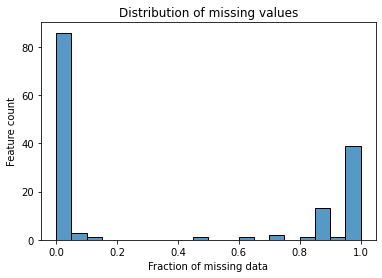

```python
sns.histplot(data = missing_values_fraction, bins = 20)
plt.title("Distribution of missing values")
plt.xlabel('Fraction of missing data')
plt.ylabel('Feature count')
```

From the histogram above we can that there is a large gap between features with less than 15% of missing values and tose with more than 40%. Since it is difficult to accurately impute data with more than 20% of the values missing, we drop these features from our dataset.

Storing all the variables with more than 20% missing values in a list to drop them

```python
feature_drop_list = sorted(list(missing_values_fraction[missing_values_fraction > 0.2].index))
print(feature_drop_list)
```

```
['all_util', 'annual_inc_joint', 'debt_settlement_flag_date', 'deferral_term', 'desc', 'dti_joint', 'hardship_amount', 'hardship_dpd', 'hardship_end_date', 'hardship_last_payment_amount', 'hardship_length', 'hardship_loan_status', 'hardship_payoff_balance_amount', 'hardship_reason', 'hardship_start_…
```

Checking the length of the list to see how many features will be dropped

```python
len(feature_drop_list)
```

```
58
```

Dropping 58 features making the dataset much more easier to understand and build stronger models on

```python
loan_df.drop(labels=feature_drop_list, axis = 1, inplace = True)
```

```python
loan_df.shape
```

```
(176081, 90)
```

### 3.2 Keep features that are easily understood

Since no data dictionary is provided to understand the features, we will retain features easily understood and look useful after intial inspection of the features.

```python
final_features_list = ['loan_amnt','term','int_rate','installment','grade','home_ownership','annual_inc','addr_state',
                       'dti','earliest_cr_line','revol_util','total_acc','last_fico_range_high',
                       'last_fico_range_low','emp_length','loan_status']
```

```python
len(final_features_list)
```

```
16
```

```python
features_to_drop = [col_name for col_name in loan_df.columns if col_name not in final_features_list]
print(features_to_drop)
```

```
['id', 'funded_amnt', 'funded_amnt_inv', 'sub_grade', 'emp_title', 'verification_status', 'issue_d', 'pymnt_plan', 'zip_code', 'delinq_2yrs', 'fico_range_low', 'fico_range_high', 'inq_last_6mths', 'open_acc', 'pub_rec', 'revol_bal', 'initial_list_status', 'out_prncp', 'out_prncp_inv', 'total_pymnt',…
```

Dropping the features

```python
loan_df.drop(labels=features_to_drop, axis=1, inplace=True)
loan_df.shape
```

```
(176081, 16)
```

Since highly correlated features do not add any value and are redundant we will identify and eliminate highly correlated variables

Selecting all the numeric features to check for high correlation

```python
numerical_features=loan_df.select_dtypes(include=['int64','float64'])
numerical_features.shape
```

```
(176081, 9)
```

#### 3.3.1 Heatmap of numeric variables

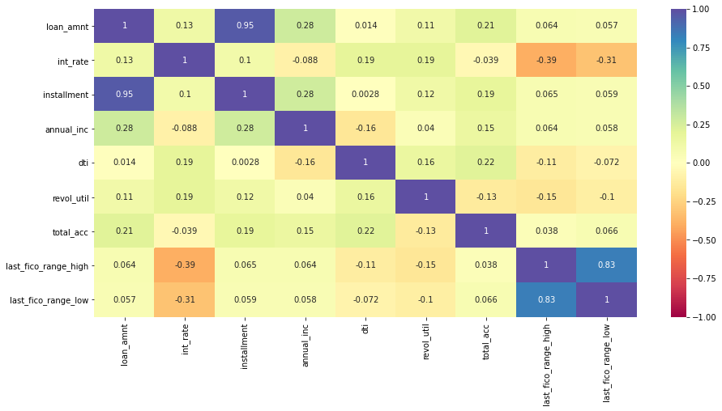

```python
plt.figure(figsize=(15,7))
sns.heatmap(numerical_features.corr(),annot=True, cmap='Spectral', vmin=-1, vmax=1)
plt.show()
```

Reference: https://www.dummies.com/article/academics-the-arts/math/statistics/how-to-interpret-a-correlation-coefficient-r-169792/

There is correlation between certain numerical features. Here we consider variables with correlations greater than 0.70 to be highly correlated. The variables with high correlation are:

```
a)loan_amnt and installment : 0.95
b)last_fico_range_high and last_fico_range_high:0.83
```

The high correlations are as expected. The installment is dependent on the loan amount and the fico scores are also related as it is for the same individual. We will drop the installment variable and handle the fico score related variables at a later stage

Dropping the installment variable from the dataset

```python
loan_df.drop(labels='installment', axis=1, inplace=True)
loan_df.shape
```

```
(176081, 15)
```

Lets plot a pair plot to visualize the distribution of all the numeric features

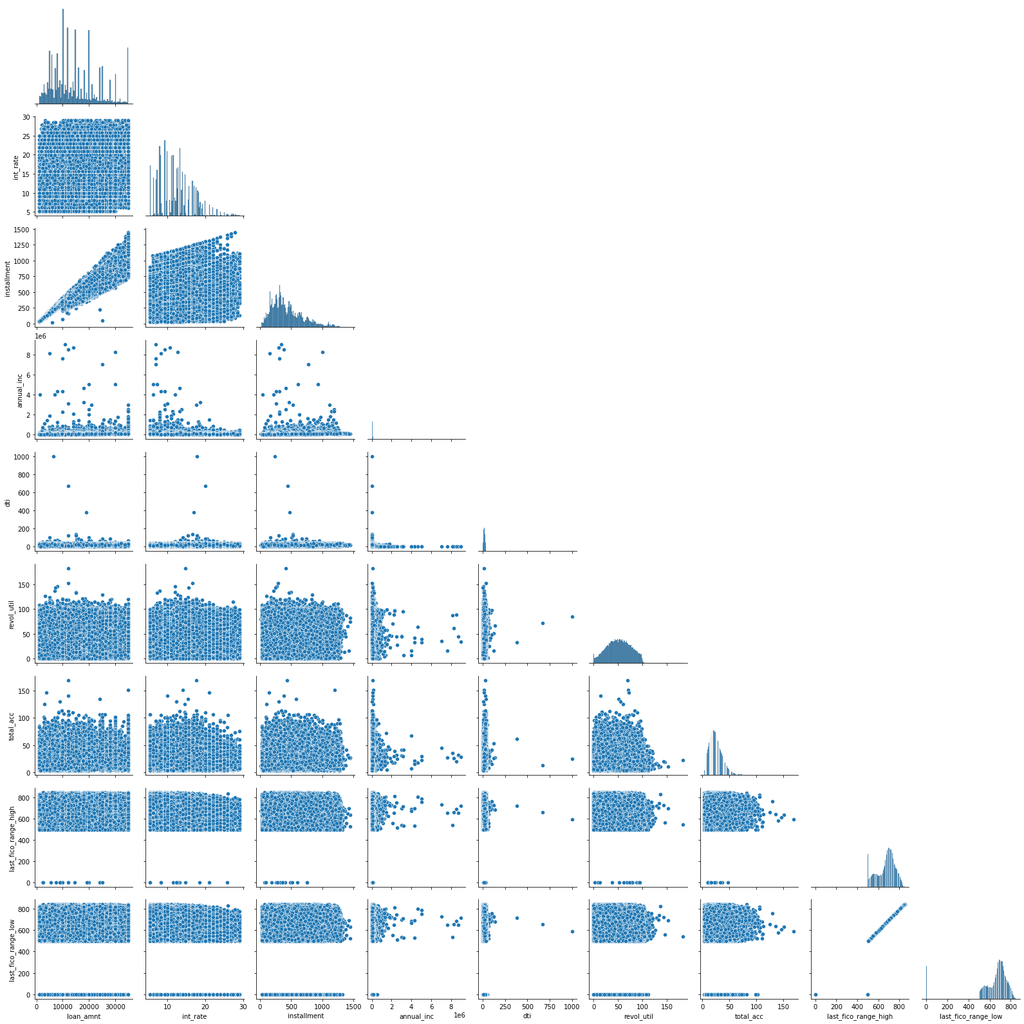

```python
sns.pairplot(data=numerical_features, corner=True);
```

We observe that the numerical features are not normally distributed and hence we have to normalize them before training our model

## 4.Exploratory Analysis

In this step we will visualize the final list of variables to better understand the data and its distributions

Checking for features and their datatypes for our final dataset

```python
loan_df.info()
```

```
<class 'pandas.core.frame.DataFrame'>
Int64Index: 176081 entries, 0 to 199998
Data columns (total 15 columns):
 #   Column                Non-Null Count   Dtype
---  ------                --------------   -----
 0   loan_amnt             176081 non-null  int64
 1   term                  176081 non-null  object
 2   int_rate              176081 non-null  float64
 3   grade                 176081 non-null  object
 4   emp_length            164947 non-null  object
 5   home_ownership        176081 non-null  object
 6   annual_inc            176081 non-null  float64
 7   loan_status           176081 non-null  object
 8   addr_state            176081 non-null  object
 9   dti                   176079 non-null  float64
 10  earliest_cr_line      176081 non-null  object
 11  revol_util            176012 non-null  float64
 12  total_acc             176081 non-null  int64
 13  last_fico_range_high  176081 non-null  int64
 14  last_fico_range_low   176081 non-null  int64
dtypes: float64(4), int64(4), object(7)
memory usage: 21.5+ MB
```

### 4.1 Loan Amount

Looking at the distriution of loan amount by loan status

```python
loan_df.groupby('loan_status')['loan_amnt'].describe()
```

| loan_status | count | mean | std | min | 25% | 50% | 75% | max |
| --- | --- | --- | --- | --- | --- | --- | --- | --- |
| Charged Off | 35090.00 | 15772.15 | 8587.57 | 1000.00 | 9600.00 | 15000.00 | 21000.00 | 35000.00 |
| Fully Paid | 140991.00 | 14332.98 | 8599.22 | 1000.00 | 7800.00 | 12000.00 | 20000.00 | 35000.00 |

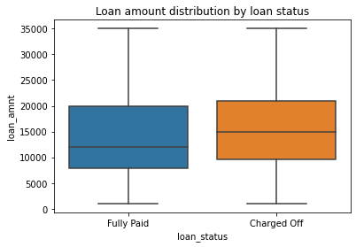

```python
plt.title('Loan amount distribution by loan status')
sns.boxplot(data=loan_df, y='loan_amnt', x='loan_status');
```

Charged off loans seem to have a higher loan amounts

### 4.2 Term

```python
loan_df['term'].value_counts(dropna = False)
```

```
 36 months    134499
 60 months     41582
Name: term, dtype: int64
```

Converting the term to integer

```python
loan_df['term'] = loan_df['term'].apply(lambda s: np.int8(s.split()[0]))
```

```python
loan_df['term'].value_counts(normalize=True)*100
```

```
36   76.38
60   23.62
Name: term, dtype: float64
```

Looking at the term value for charged-off loans

```python
loan_df.groupby('term')['loan_status'].value_counts(normalize=True).loc[:,'Charged Off']
```

```
term
36   0.15
60   0.37
Name: loan_status, dtype: float64
```

About 76% of the completed loans have 3 year period and the rest have 5 year period.Loans with 5 year periods are more than twice as likely to charge-off as loans with 3 year periods.

### 4.3 Interest rate

Looking at the distriution of interest rate by loan status

```python
loan_df.groupby('loan_status')['int_rate'].describe()
```

| loan_status | count | mean | std | min | 25% | 50% | 75% | max |
| --- | --- | --- | --- | --- | --- | --- | --- | --- |
| Charged Off | 35090.00 | 14.73 | 4.31 | 5.32 | 11.99 | 13.99 | 17.86 | 28.99 |
| Fully Paid | 140991.00 | 11.46 | 3.95 | 5.32 | 8.18 | 11.22 | 13.67 | 28.99 |

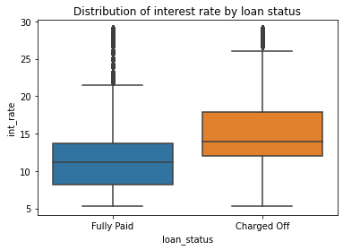

```python
plt.title('Distribution of interest rate by loan status')
sns.boxplot(data =loan_df, y='int_rate', x='loan_status');
```

Charged off loans have much higher interest rate compared to loans that are fully paid

### 4.4 Grade

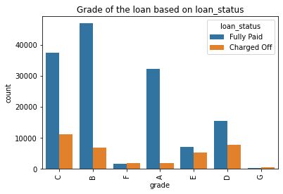

```python
plt.title('Grade of the loan based on loan_status')
sns.countplot(data=loan_df, x='grade', hue='loan_status')
plt.xticks(rotation = 90);
```

```python
loan_df.groupby('grade')['loan_status'].value_counts(normalize=True).loc[:,'Charged Off']
```

```
grade
A   0.05
B   0.13
C   0.23
D   0.33
E   0.43
F   0.52
G   0.58
Name: loan_status, dtype: float64
```

There is clear trend that there is a higher probability of a charge off as the grade of the loan worsens

### 4.5 Employment length

```python
loan_df['emp_length'].value_counts(dropna=False).sort_index()
```

```
1 year       11695
10+ years    58403
2 years      15560
3 years      14068
4 years      10160
5 years      10523
6 years       6913
7 years       6934
8 years       8956
9 years       6848
< 1 year     14887
NaN          11134
Name: emp_length, dtype: int64
```

Note: There are 11,134 loans without information on the employment length of the borrower

Converting emp_length to integer

```python
loan_df['emp_length'].replace('< 1 year', '0 years', inplace=True)
```

```python
loan_df['emp_length'].replace(to_replace='10+ years', value='10 years', inplace=True)
```

```python
loan_df['emp_length'] = loan_df['emp_length'].replace('(years|year)','',regex=True).apply(float)
```

```python
loan_df['emp_length'].value_counts(dropna=False).sort_index()
```

```
0.00     14887
1.00     11695
2.00     15560
3.00     14068
4.00     10160
5.00     10523
6.00      6913
7.00      6934
8.00      8956
9.00      6848
10.00    58403
NaN      11134
Name: emp_length, dtype: int64
```

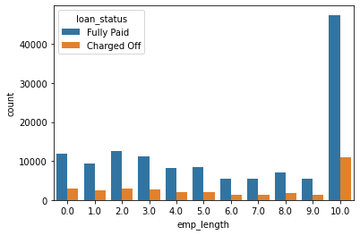

```python
sns.countplot(data=loan_df, x='emp_length', hue ='loan_status');
```

### 4.6 Home Ownership

```python
loan_df.groupby('home_ownership')['loan_status'].value_counts(normalize = True)
```

```
home_ownership  loan_status
ANY             Fully Paid    1.00
MORTGAGE        Fully Paid    0.83
                Charged Off   0.17
OWN             Fully Paid    0.79
                Charged Off   0.21
RENT            Fully Paid    0.77
                Charged Off   0.23
Name: loan_status, dtype: float64
```

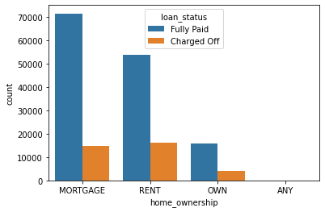

```python
sns.countplot(data = loan_df, x = 'home_ownership', hue = 'loan_status');
```

### 4.7 Annual Income

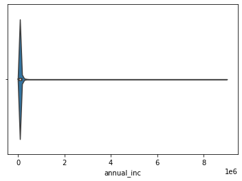

```python
sns.violinplot(data = loan_df, x = 'annual_inc');
```

As the distribution of the variable is highly skewed based on the above boxplot, we need to perform log transformation to reduce the skewness

```python
loan_df['log_annual_inc'] =loan_df['annual_inc'].apply(lambda x: np.log10(x+1))
```

```python
loan_df.drop('annual_inc', axis=1, inplace = True)
```

```python
loan_df['log_annual_inc'].describe()
```

```
count   176081.00
mean         4.82
std          0.24
min          0.00
25%          4.66
50%          4.81
75%          4.96
max          6.95
Name: log_annual_inc, dtype: float64
```

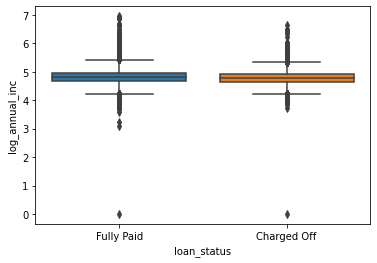

```python
sns.boxplot(data=loan_df, x='loan_status', y='log_annual_inc');
```

```python
loan_df.groupby('loan_status')['log_annual_inc'].describe()
```

| loan_status | count | mean | std | min | 25% | 50% | 75% | max |
| --- | --- | --- | --- | --- | --- | --- | --- | --- |
| Charged Off | 35090.00 | 4.79 | 0.23 | 0.00 | 4.65 | 4.78 | 4.93 | 6.63 |
| Fully Paid | 140991.00 | 4.83 | 0.24 | 0.00 | 4.67 | 4.82 | 4.98 | 6.95 |

It appears that the annual income between borrowers of different loan status is very similar as they have almost the same median values for the annual income

### 4.8 Address State

```python
loan_df.groupby('addr_state')['loan_status'].value_counts(normalize = True).loc[:,'Charged Off'].sort_values()
```

```
addr_state
OR   0.14
ME   0.14
NH   0.14
VT   0.14
DC   0.15
CO   0.16
WA   0.16
SC   0.16
WV   0.16
CT   0.17
KS   0.17
MT   0.18
MA   0.18
GA   0.18
WY   0.18
IL   0.18
WI   0.18
RI   0.18
UT   0.19
DE   0.19
VA   0.19
CA   0.20
AZ   0.20
AK   0.20
MN   0.20
MI   0.20
HI   0.20
TX   0.21
NC   0.21
PA   0.21
FL   0.21
MD   0.21
ND   0.21
TN   0.21
NY   0.21
KY   0.21
IN   0.21
NM   0.21
OH   0.21
MO   0.22
NJ   0.22
NV   0.22
LA   0.24
AL   0.24
MS   0.25
NE   0.25
SD   0.25
AR   0.26
OK   0.26
Name: loan_status, dtype: float64
```

The Charge off rate is higher in some of the mid-western states like Mississipi, Nebraska, Arkansas, South Dakota and Oklahoma

### 4.9 DTI-Debt to income ratio

The lower the DTI, the less risky the borrowers are to lenders.

```python
loan_df.groupby('loan_status')['dti'].describe()
```

| loan_status | count | mean | std | min | 25% | 50% | 75% | max |
| --- | --- | --- | --- | --- | --- | --- | --- | --- |
| Charged Off | 35089.00 | 21.02 | 8.84 | 0.00 | 14.42 | 20.85 | 27.70 | 67.50 |
| Fully Paid | 140990.00 | 18.39 | 9.19 | 0.00 | 11.88 | 17.75 | 24.39 | 999.00 |

Charged-off loans seem to have a slightly higher DTI making the borrowers more risky and less financially stable

### 4.10 Earliest credit line

```python
loan_df['earliest_cr_line'].sample(5)
```

```
178520    Jun-01
197783    May-98
134101    Dec-95
131461    Nov-07
100256    Aug-09
Name: earliest_cr_line, dtype: object
```

```python
#simple function to convert
def year_2to4_digit(year):
    return 1900+year if year > 22 else 2000+year
```

Converting the month and year to year with 4 digits

```python
loan_df['earliest_cr_line'] = loan_df['earliest_cr_line'].replace('[A-Za-z\-]','',regex=True).apply(int)
loan_df['earliest_cr_line'] = loan_df['earliest_cr_line'].apply(year_2to4_digit)
loan_df['earliest_cr_line'].sample(5)
```

```
160847    1989
116755    1996
117342    2008
91076     2004
168590    1996
Name: earliest_cr_line, dtype: int64
```

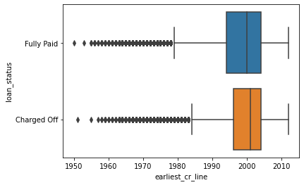

```python
sns.boxplot(data = loan_df, x='earliest_cr_line', y='loan_status');
```

Borrowers who are charged off tend to have shorter period of credit line history

### 4.11 Total accounts

```python
loan_df.groupby('loan_status')['total_acc'].describe()
```

| loan_status | count | mean | std | min | 25% | 50% | 75% | max |
| --- | --- | --- | --- | --- | --- | --- | --- | --- |
| Charged Off | 35090.00 | 25.66 | 12.47 | 4.00 | 17.00 | 24.00 | 33.00 | 169.00 |
| Fully Paid | 140991.00 | 25.14 | 12.04 | 4.00 | 16.00 | 23.00 | 32.00 | 146.00 |

No large differences in the number of credit lines in the borrowers of differnt loan status

### 4.12 Revolving line of utilization

```python
loan_df.groupby('loan_status')['revol_util'].describe()
```

| loan_status | count | mean | std | min | 25% | 50% | 75% | max |
| --- | --- | --- | --- | --- | --- | --- | --- | --- |
| Charged Off | 35076.00 | 54.74 | 23.62 | 0.00 | 37.40 | 55.30 | 72.70 | 182.80 |
| Fully Paid | 140936.00 | 51.52 | 24.07 | 0.00 | 33.40 | 51.20 | 69.80 | 152.50 |

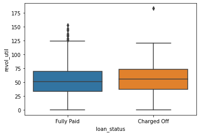

```python
sns.boxplot(data = loan_df, x='loan_status',y='revol_util');
```

Borrowers with charged off loans have higher value for the credit utilization rate indicating they use more credit to make purchases

### 4.14 Fico score

Since the fico scores are highly correlated we will take the average of the low and high scores to reduce the feature count

```python
loan_df['fico_score'] = 0.5*loan_df['last_fico_range_low']+0.5*loan_df['last_fico_range_high']
```

```python
loan_df.drop(labels = ['last_fico_range_low','last_fico_range_high'], axis=1, inplace = True)
```

```python
loan_df.groupby('loan_status')['fico_score'].describe()
```

| loan_status | count | mean | std | min | 25% | 50% | 75% | max |
| --- | --- | --- | --- | --- | --- | --- | --- | --- |
| Charged Off | 35090.00 | 533.03 | 113.67 | 0.00 | 522.00 | 557.00 | 592.00 | 832.00 |
| Fully Paid | 140991.00 | 702.07 | 65.60 | 0.00 | 672.00 | 707.00 | 742.00 | 847.50 |

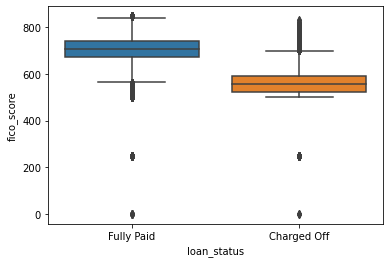

```python
sns.boxplot(data = loan_df, x='loan_status', y='fico_score');
```

Borrowers with charged off loans have lower median credit score compared to borrowers with fully paid loans

## 5 Pre-processing

### 5.1 Converting categorical columns to dummy variables

```python
loan_df = pd.get_dummies(loan_df,columns=['grade','home_ownership','addr_state'], drop_first=True)
```

### 5.2 Convert loan status to 0/1 indicator

0 indicates fully paid and 1 indicates that the loan was charged off

```python
loan_df['loan_status'] = loan_df['loan_status'].replace(to_replace=['Fully Paid', 'Charged Off'], value=[0, 1])
```

## 6 Model Training and Evaluation

We will build the models using the following algorithms and evaluate them

```
1) Logistic Regression
2) Random Forest
```

### 6.1 Training and Test dataset

```python
response = loan_df['loan_status']
```

```python
loan_df.drop(labels ='loan_status',axis=1,inplace= True)
```

```python
#Creating a train-test split for model building (70-30 split)
X_train, X_test, y_train, y_test = train_test_split(loan_df, response, stratify=response, test_size=0.30,random_state=123)
```

### 6.2 Logistic Regression Pipeline

```python
pipeline_logistic = Pipeline([
    ('imputer', SimpleImputer(copy=False)),
    ('scaler', StandardScaler(copy=False)),
    ('model', SGDClassifier(loss='log', max_iter=1000, tol=0.0001, random_state=1, warm_start=True))
])
```

Grid search parameters

```python
param_grid_logistic = {
    'model__alpha': [0.0001,0.001,0.01,0.1],
    'model__penalty': ['l1', 'l2']
}
```

Creating the search grid

```python
grid_logistic = GridSearchCV(estimator=pipeline_logistic, param_grid=param_grid_logistic,
                             scoring='roc_auc', n_jobs=1, pre_dispatch=1, cv=5, verbose=1, return_train_score=False)
```

#### 6.2.1 Fitting the logistic regression model

```python
grid_logistic.fit(X_train,y_train)
```

```
Fitting 5 folds for each of 8 candidates, totalling 40 fits
```

```
GridSearchCV(cv=5,
             estimator=Pipeline(steps=[('imputer', SimpleImputer(copy=False)),
                                       ('scaler', StandardScaler(copy=False)),
                                       ('model',
                                        SGDClassifier(loss='log',
                                                      random_state=1,
                                                      warm_start=True))]),
             n_jobs=1,
             param_grid={'model__alpha': [0.0001, 0.001, 0.01, 0.1],
                         'model__penalty': ['l1', 'l2']},
             pre_dispatch=1, scoring='roc_auc', verbose=1)
```

Mean cross-validated ROC_AUC score of the best model

```python
grid_logistic.best_score_
```

```
0.9563602927869237
```

Best Hyper Parameters

```python
grid_logistic.best_params_
```

```
{'model__alpha': 0.001, 'model__penalty': 'l2'}
```

### 6.3 Random Forest

```python
pipeline_rf = Pipeline([
    ('imputer', SimpleImputer(copy=False)),
    ('model', RandomForestClassifier(n_jobs=-1, random_state=1))
])
```

Grid Search parameters

```python
param_grid_rf = {
    'model__n_estimators': [50,100] # The number of randomized trees to build
}
```

Creating the search grid

```python
grid_rf = GridSearchCV(estimator=pipeline_rf, param_grid=param_grid_rf,
                        scoring='roc_auc', n_jobs=1, pre_dispatch=1, cv=5, verbose=1, return_train_score=False)
```

#### 6.3.1 Fitting the random forest model

```python
grid_rf.fit(X_train,y_train)
```

```
Fitting 5 folds for each of 2 candidates, totalling 10 fits
```

```
GridSearchCV(cv=5,
             estimator=Pipeline(steps=[('imputer', SimpleImputer(copy=False)),
                                       ('model',
                                        RandomForestClassifier(n_jobs=-1,
                                                               random_state=1))]),
             n_jobs=1, param_grid={'model__n_estimators': [50, 100]},
             pre_dispatch=1, scoring='roc_auc', verbose=1)
```

Mean cross-validated ROC_AUC score of the best model

```python
grid_rf.best_score_
```

```
0.9533919313714003
```

Best Hyper Parameters

```python
grid_rf.best_params_
```

```
{'model__n_estimators': 100}
```

## 7 Evaluation on test set

Since logistic regression model has a slightly higher ROC_AUC value we will use the logistic model to evaluate on the test dataset

```python
y_pred=grid_logistic.predict_proba(X_test)[:,1]
```

```python
roc_auc_score(y_test, y_pred)
```

```
0.9550764300088805
```

The test set ROC_AUC is very close to the cross-validated score indicating a good model fit

## 8 Limitations and Conclusion

In this project we used the given variables to build machine learning models with good accuracy. Although both logistic and random forest performed well we still have to consider the results with a grain of salt as not all the features were utilized. Some features were dropped because of missing values which were beyond imputation, but we excluded certain variables because of the lack of data dictionary.Including more variables might help in making the model more robust and accurate and should be tested before we accept the above results.